# Combined A2SF Analysis

viwa

2024-08-30

### Combining Survey Results

*Combine surveys into one data frame, with labels to group surveys by collection time frame.*

#### Where are visitors from?

*Pie chart of all zip codes represented by respondents.*

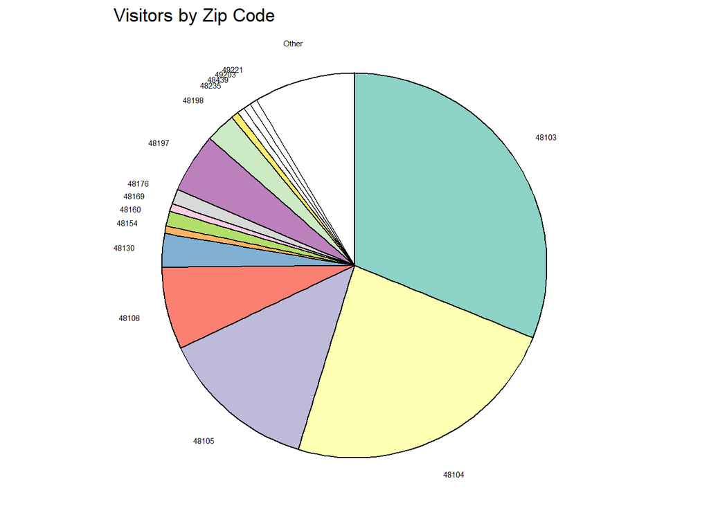

*All visitors, by county of origin. NOTE: numbers above bars represent the proportion of visitors from represented counties.*

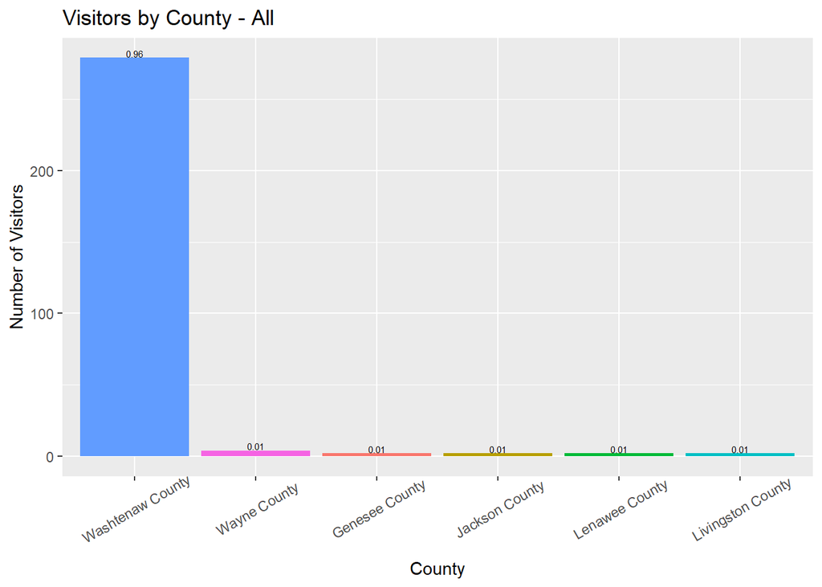

#### What ages are visitors?

*Bar graph of visitors by the survey source.*

Rationale: Differently-aged visitor groups may vary across collection method. Both surveys were administered online, but patrons were reached out in-person for in-season responses or online via email and social media for post-season responses. This can lead to variability that needs to be assessed.

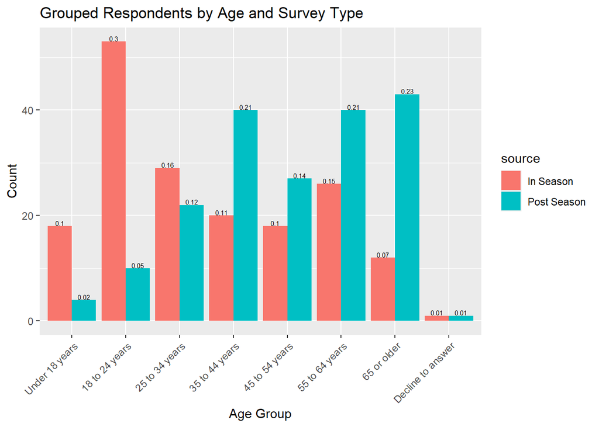

*Is there a statistical difference between age-group demographics for in-season vs post-season respondents?*

Using the eye test, older age groups *seem* to answer more in the post-season, while younger groups were over-sampled in the in-season group. We need to verify this statistically using a chi-square test to demonstrate the response behaviors may vary between response groups. The Pearson’s Chi-squared test indicates that there is a difference in respondents by age group between the two survey sources.

```
##
##  Pearson's Chi-squared test
##
## data:  contingency_table
## X-squared = 67.905, df = 7, p-value = 3.913e-12
```

*Perform pairwise chi-squared tests and adjust the p-values using Bonferroni correction.*

Without adjustments, performing multiple pairwise tests increases the likelihood of finding at least one significant result purely by chance.

The Bonferroni correction adjusts the significance level for each individual test by dividing the desired overall significance level (e.g., 0.05) by the number of comparisons. This reduces the likelihood of Type I errors but may be conservative and reduce power.

If the overall chi-squared test (or another omnibus test) is significant, it indicates that not all groups are equal, prompting the need to find out where those differences lie.

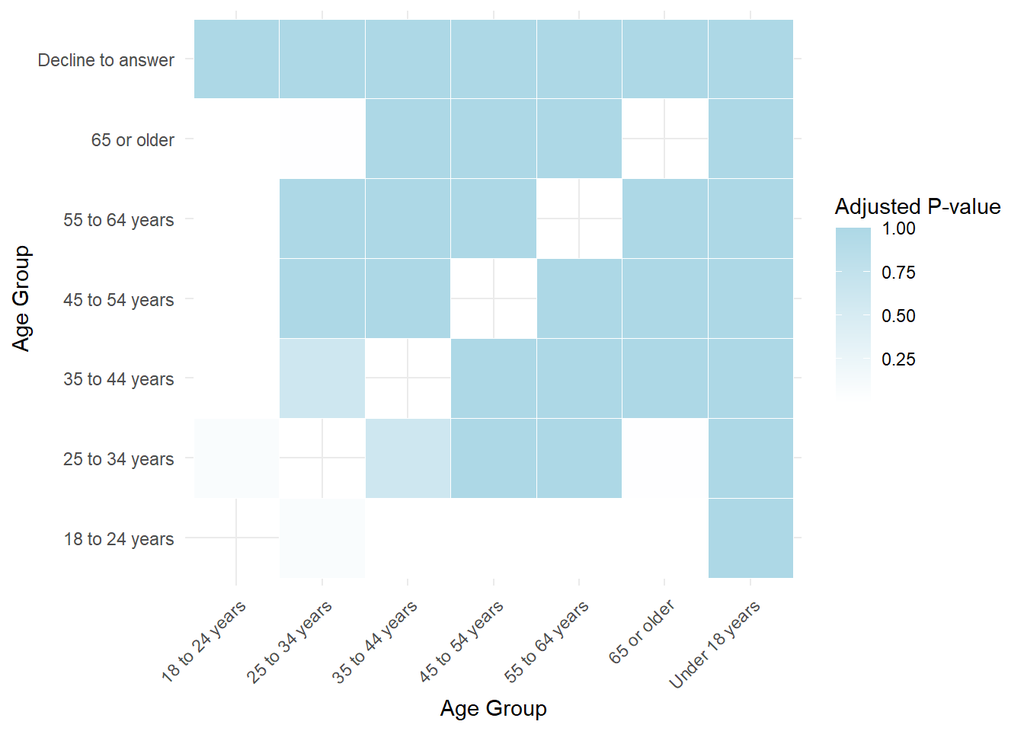

#### Visitor gender demographics

*Bar graph of number of visitors by their self-identified gender.*

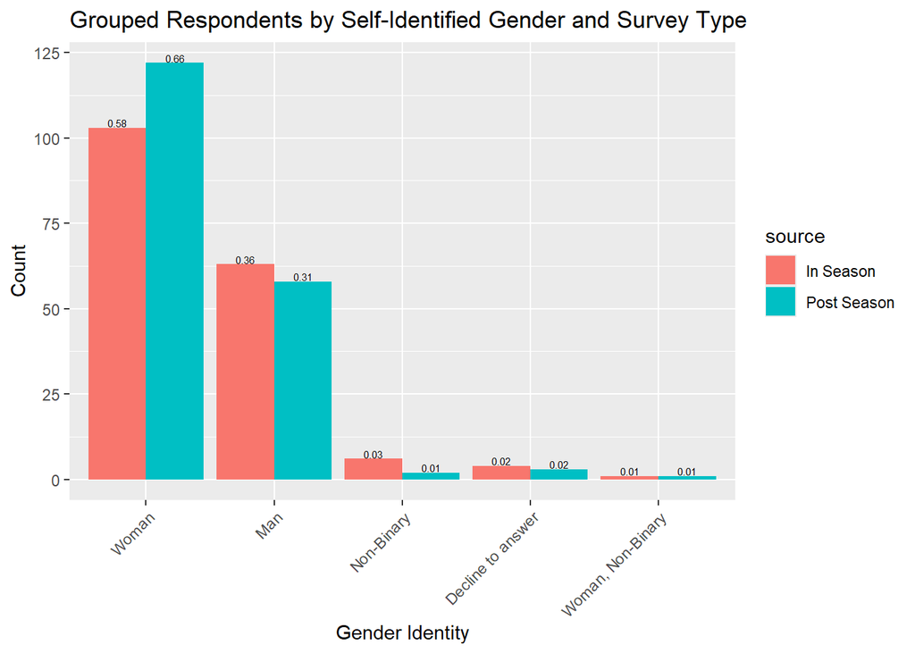

*Other self-described gender identities.*

| Survey | Other Identity | Count |
| --- | --- | --- |
| In Season | Gender fluid | 1 |

#### Visitor Race/Ethnicity demographics

*All distinct race/ethnicity identities*

| Race/Ethnicity |
| --- |
| American Indian or Alaska Native |
| American Indian or Alaska Native, Hispanic, Latino or Spanish origin, White |
| American Indian or Alaska Native, White |
| Asian |
| Asian, Hispanic, Latino or Spanish origin |
| Asian, White |
| Asian, White, Mixed heritage |
| Black or African American |
| Black or African American, Asian |
| Black or African American, Hispanic, Latino or Spanish origin |
| Black or African American, White |
| Black or African American, White, Mixed heritage |
| Decline to answer |
| Hispanic, Latino or Spanish origin |
| Hispanic, Latino or Spanish origin, White |
| Middle Eastern and North African (MENA) |
| Middle Eastern and North African (MENA), Mixed heritage |
| Mixed heritage |
| White |
| White, Middle Eastern and North African (MENA) |
| White, Mixed heritage |

*Ethnicity question.*

| Ethnicity | Count | Percent (%) |
| --- | --- | --- |
| Hispanic, Latino or Spanish origin | 23 | 6.32 |
| NOT Hispanic, Latino or Spanish origin | 341 | 93.68 |

*Bar graph of race/ethnicity identities, by survey, with mixed heritages collapsed into a single general category. Does not include Hispanic, Latino, or Spanish origin, as this is used to assess “ethnicity” separately, per US Census standards.*

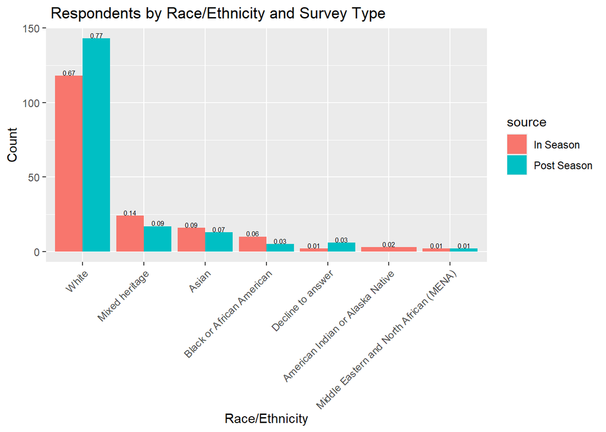

| Race | Frequency | Percent (%) |
| --- | --- | --- |
| White | 261 | 72.30 |
| Mixed heritage | 41 | 11.36 |
| Asian | 29 | 8.03 |
| Black or African American | 15 | 4.16 |
| Decline to answer | 8 | 2.22 |
| Middle Eastern and North African (MENA) | 4 | 1.11 |
| American Indian or Alaska Native | 3 | 0.83 |

*Is race/ethnicity breakdown different by source?*

```
##
##  Pearson's Chi-squared test
##
## data:  contingency_table
## X-squared = 23.058, df = 20, p-value = 0.286
```

*Other race/ethnicity identities, as self-described by respondents.*

| Survey | Other Identities | Count |
| --- | --- | --- |
| In Season | Carribbean | 1 |
| In Season | Jewish | 2 |
| Post Season | Filipino | 1 |
| Post Season | Italian-American | 1 |
| Post Season | Race is a construct. | 1 |

*All favorite offering counts by respondents.*

| Offering | Frequency | Percent (%) |
| --- | --- | --- |
| Music at Top of the Park | 122 | 30.58 |
| Food Selections | 79 | 19.80 |
| The Grove Beverage Garden | 54 | 13.53 |
| Movies by Moonlight | 47 | 11.78 |
| Special Outdoor Attractions | 45 | 11.28 |
| Teen and Adult Activities | 14 | 3.51 |
| KidZone | 11 | 2.76 |
| Retreat Classes on Power Center lawn | 8 | 2.01 |
| I was invited to an event in the party tent | 6 | 1.50 |
| CHELAS | 1 | 0.25 |
| Can Chelas be allowed to sell orchatas? | 1 | 0.25 |
| Great overall vibe | 1 | 0.25 |
| Gregory Alan Isakov!!!! and Mon Rovia! | 1 | 0.25 |
| Juggling | 1 | 0.25 |
| Reflex | 1 | 0.25 |
| Spoken word night | 1 | 0.25 |
| This survey | 1 | 0.25 |
| Ticketed offerings have fallen off significantly in volume and alignment with my intetrests. | 1 | 0.25 |
| Tuesday's Tastings | 1 | 0.25 |
| loved the silent films | 1 | 0.25 |
| meet up with friends, people I have not seen for a long while; listen to god entertainment, dance outdoors | 1 | 0.25 |
| trivia! | 1 | 0.25 |